# Workshop Week 13

Author

Affiliation

STAT5003

School of Mathematics and Statistics

# 1 Learning Outcomes

**Learning Outcomes**

- Implement Markov Chain Monte Carlo techniques to:
  1. Compute a posterior distribution
  2. Generate samples from a non-trivial density

**Unit of study surveys**

Your tutors will step outside allowing time for you to complete the [unit of study survey and/or feedback for teachers survey](https://student-surveys.sydney.edu.au/students/). We value your feedback and appreciate constructive comments about what is working well and what can be improved to make the experience better for students in the future.

# 2 Compute chance of a coin flip

**Simulate some data**

Below is a way to simulate coin flips with chance of success $\theta = p = 0.7$ but you can use other simulated data if you wish. Denote these simulated values as the random variables $X_1, X_2, \ldots, X_n$ where $n = 200$

```r
set.seed(5003)
theta = 0.7 # P(Head)
N = 200
# simulate some coin flips
coin.flips <- rbinom(n = N, size = 1, prob = theta)
```

**Determine how to compute the Likelihood of the parameter**

Recall the Likelihood approach covered in earlier weeks. In this case, each observation is assumed to be drawn from a Bernoulli (Binomial with $n = 1$) distribution. The formula is,

$$P(X = x \mid \theta) =
\begin{cases}
\theta^x (1 - \theta)^{1 - x}, & \text{if } x = 0 \text{ or } 1; \\
0, & \text{otherwise}.
\end{cases}$$

and it can be computed with `dbinom`. Write a function that computes the Likelihood of the parameter $\theta$ given all of the observed data.

$L(\theta|X_1, X_2,\ldots, X_n) = \prod_{i = 1}^n P(X = x_i|\theta)$

```r
likelihood <- function(theta, x){
  <your code here>
}
```

```r
likelihood <- function(theta, x)
  prod(dbinom(x, size = 1, prob = theta))
```

**Naive Metropolis Hastings**

Write a Metropolis-Hastings algorithm that starts from a specified initial value for the parameter $\theta$ (or a randomly chosen one, if preferred), and uses a random walk sampler to propose new values. For simplicity, it is recommended to use a Gaussian distribution as the proposal density $q$.

The pseudo-code provided below outlines the basic Metropolis-Hastings steps but will need refinement. In particular, proposed values of $\theta$ must lie strictly within the interval (0,1), so the algorithm should include a check or adjustment to reject or correct any invalid proposals. You may assume a uniform prior distribution for $\theta$ over the interval [0,1].

```r
# In this example, we set the prior of P(Head) to be a uniform distribution
niters <- 1000
curr.theta <- 0.5 # This is the parameter we want to find; initialise it

theta.chain <- numeric(niters) # Initialise the vector to be created
for(i in 0:(niters - 1)) {
  proposal.theta <- <your code here> # A random draw from the proposal density that is conditioned on the previous iteration.

    if (proposal.theta < 0 || proposal.theta > 1)
  {
      theta.chain[i + 1] <- curr.theta
      next
  } ## Add a constraint to ensure that the proposed value is between 0 and 1.

  curr.likeli <- <your code here> # computed likelihood from the current theta
  proposal.likeli <- <your code here> # computed likelihood from the proposed theta

  alpha <- min(<your code here>, 1)

   # Randomly decide whether to accept our new proposal
   if (runif(1) < alpha)
        curr.theta <- <your code here>
   theta.chain[i + 1] <- <your code here>
}
```

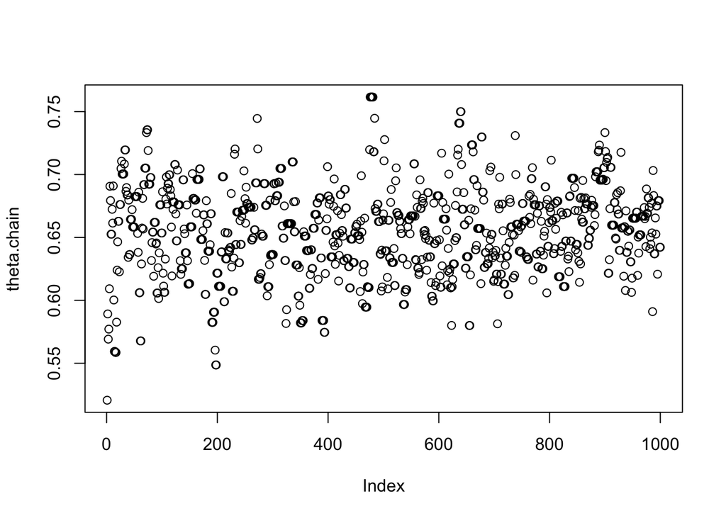

```r
niters <- 1000
curr.theta <- 0.5 # This is the parameter we want to find; initialise it

theta.chain <- numeric(niters) # Initialise the vector to be created
for(i in 0:(niters - 1)) {
  proposal.theta <- curr.theta + rnorm(1, mean = 0, sd = 0.05) # A random draw from the proposal density that is conditioned on the previous iteration.

  if (proposal.theta < 0 || proposal.theta > 1)
  {
      theta.chain[i + 1] <- curr.theta
      next
  }

  curr.likeli <- likelihood(curr.theta, coin.flips) # computed likelihood from the current theta
  proposal.likeli <- likelihood(proposal.theta, coin.flips) # computed likelihood from the proposed theta

  alpha <- min(proposal.likeli / curr.likeli, 1)

   # Randomly decide whether to accept our new proposal
   if (runif(1) < alpha)
        curr.theta <- proposal.theta
   theta.chain[i + 1] <- curr.theta
}
plot(theta.chain)
```

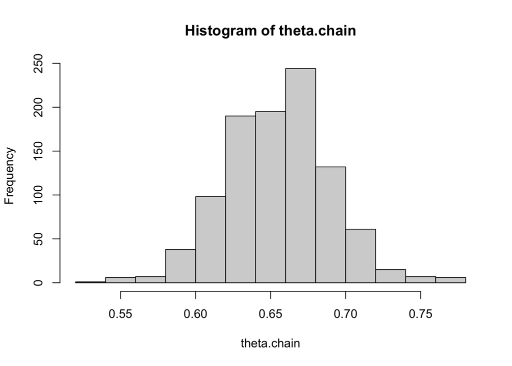

```r
hist(theta.chain)
```

If hypothetically, the computed likelihoods are too small for the machine to handle accurately (division by a small value can be unstable). Then, an alternative is to compute the product and division of the likelihood in the log domain (where it is a sum!)

**Log Likelihood computation**

The log likelihood can be computed to stabilize the computation above where the computed likelihood values fall below the `.Machine$double.eps`, roughly speaking the smallest possible value that the computer can handle with precision. (see `? .Machine`).

Write a function that computes the log-Likelihood of the parameter $\theta$ given all of the observed data.

$$\mathcal{L}(\theta|X_1, X_2,\ldots, X_n) = \log L(\theta|X_1, X_2,\ldots, X_n) = \\
\log(\prod_{i = 1}^n P(X = x_i|\theta)) = \sum_{i = 1}^n \log P(X = x_i|\theta)$$

**Hint**: The argument of `log` is useful in the `dbinom` function. (See `? dbinom`).

```r
log.likelihood <- function(theta, x) {
  <your code here>
}
```

```r
log.likelihood <- function(theta, x)
  sum(dbinom(x, size = 1, prob = theta, log = TRUE))
```

**Log likelihood computed approach to the Metropolis-Hasting algorithm**

Amend the Metropolis-Hastings algorithm above to use the log likelihood instead. Both the likelihood computations will now need to compute the log likelihood and the acceptance probability $\alpha$ will need to be modified.

```r
niters <- 1000
curr.theta <- 0.5 # This is the parameter we want to find; initialise it

theta.chain <- numeric(niters) # Initialise the vector to be created
for(i in 0:(niters - 1)) {
  proposal.theta <- <your code here> # A random draw from the proposal density that is conditioned on the previous iteration.

    # If proposed theta leaves the feasible range of values
  if(proposal.theta > 1 || proposal.theta < 0) {
     theta.chain[i + 1] <- curr.theta
     next
  }
  curr.log.likeli <- <your code here> # computed log likelihood from the current theta
  proposal.log.likeli <- <your code here> # computed log likelihood from the proposed theta

  alpha <- min(<your code here>, 1)  # This needs to be updated (hint, exp cancels out log)

   # Randomly decide whether to accept our new proposal
   if (runif(1) < alpha)
        curr.theta <- <your code here>
   theta.chain[i + 1]
}
```

```r
# In this example, we set the prior of P(Head) to be a uniform distribution
niters <- 1000
curr.theta <- 0.5 # This is the parameter we want to find; initialise it

theta.chain <- numeric(niters)
for(i in 1:niters) {
  proposal.theta <- curr.theta + rnorm(1, mean = 0, sd = 0.05)

  # If proposed theta leaves the feasible range of values
  if(proposal.theta > 1 || proposal.theta < 0) {
     theta.chain[i + 1] <- curr.theta
     next
  }

  # It is easier to work with log of probabilities
  curr.log.likeli <- log.likelihood(curr.theta, coin.flips)
  proposal.log.likeli <- log.likelihood(proposal.theta, coin.flips)

  # Because we have taken log(prob), now we need a slightly different
  # formula to get the acceptance probability. Follows from exp(log(a/b)) = exp(log(a) - log(b))
  alpha <- min(exp(proposal.log.likeli - curr.log.likeli), 1)

   # Randomly decide whether to accept our new proposal
   if (runif(1) < alpha)
        curr.theta <- proposal.theta
   theta.chain[i + 1] <- curr.theta
}
```

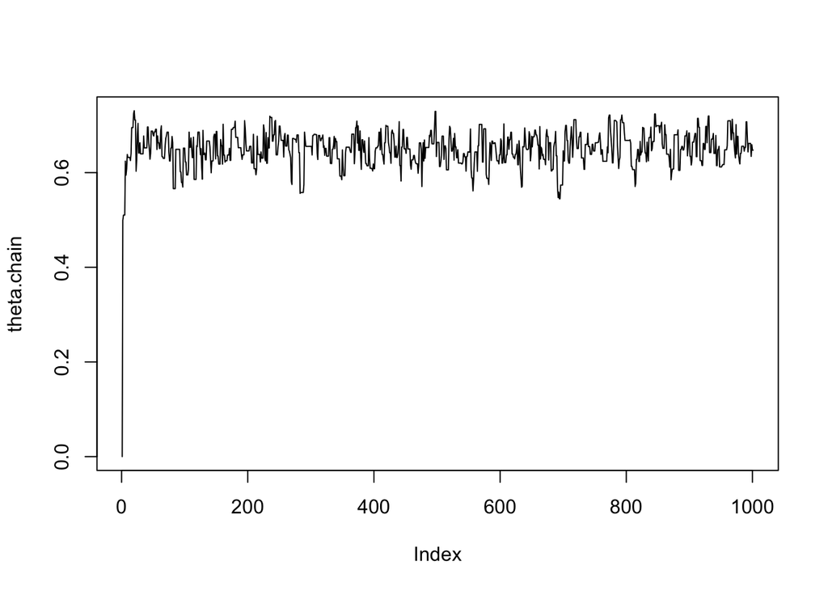

```r
plot(theta.chain, type = "l")
```

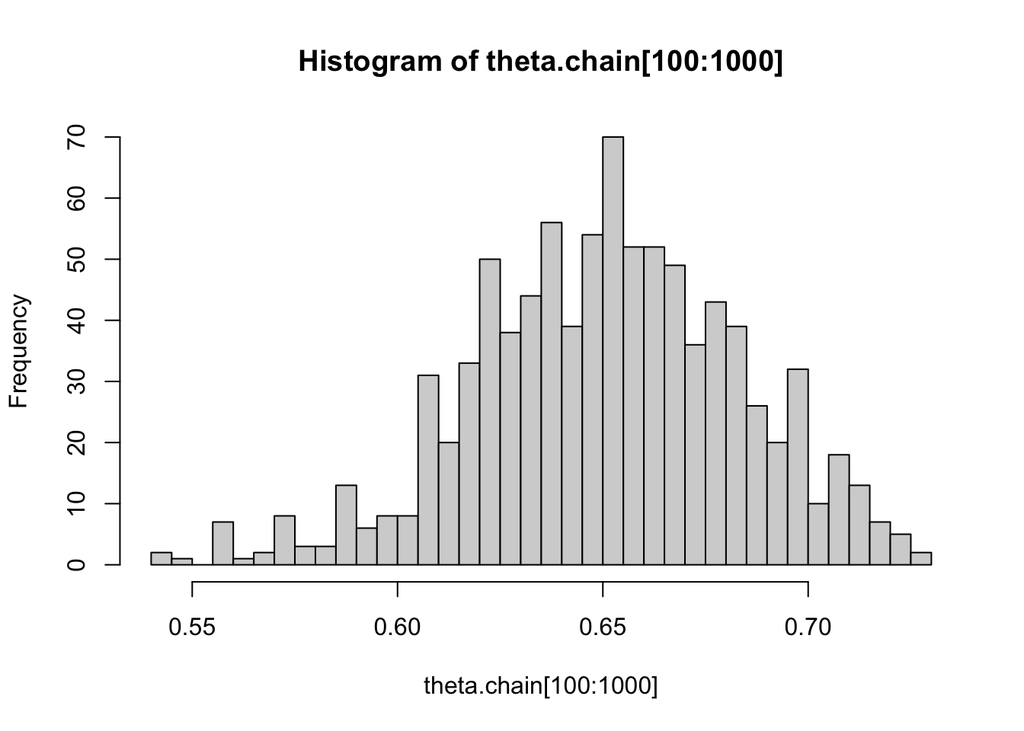

```r
hist(theta.chain[100:1000], n = 30)
```

```r
# MCMC estimates of theta after 1000 iterations
print(mean(theta.chain[100:1000]))
```

```
[1] 0.6506242
```

```r
print(sd(theta.chain[100:1000]))
```

```
[1] 0.03286099
```

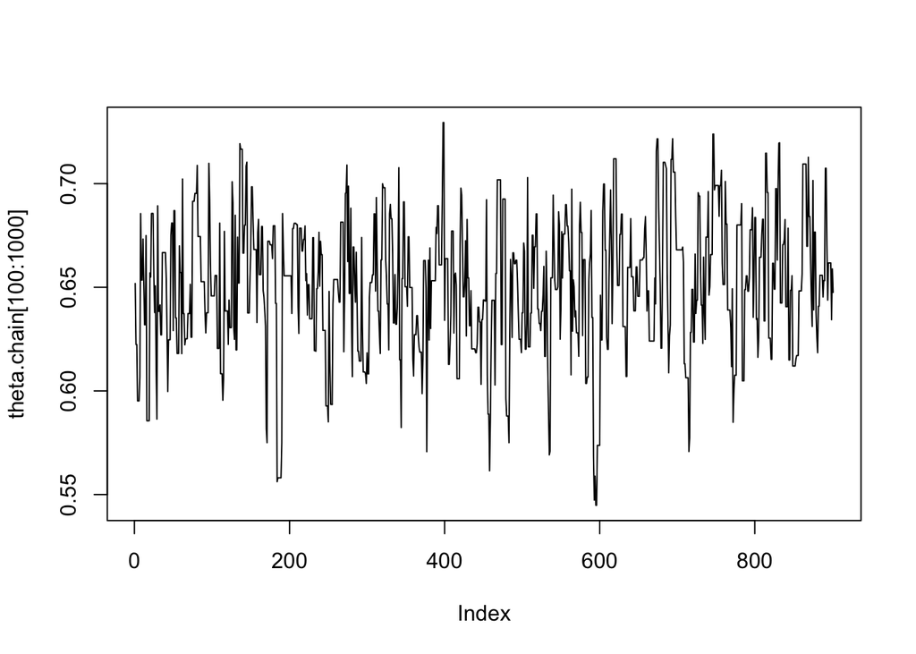

```r
plot(theta.chain[100:1000], type = 'l')
```

# 3 Generate Samples from a non-trivial distribution

Use the MCMC procedure to generate random samples from the following probability distribution function. This function is simply the sum of two normal distributions. Explore the use of the proposal distribution to explore the target space in the MCMC algorithm.

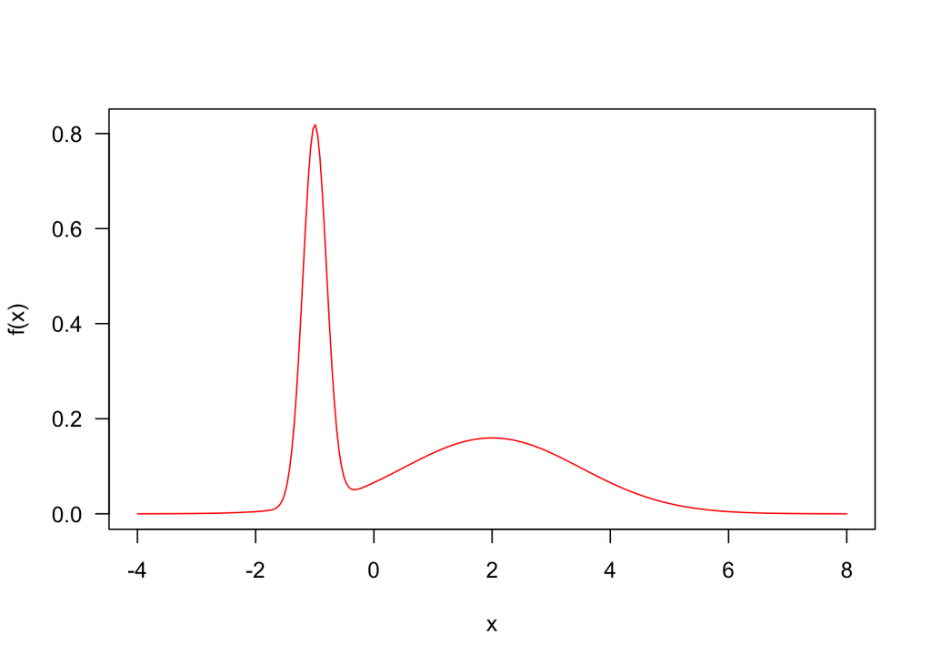

```r
p <- 0.4
mn <- c(-1, 2)
std <- c(0.2, 1.5)
f <- function(x, mu = mn, sd = std)  p * dnorm(x, mu[1], sd[1]) + (1 - p) * dnorm(x, mu[2], sd[2])

curve(f(x), col = "red", from = -4, to = 8, n = 300, las = 1)
```

**Use Metropolis-Hastings algorithm to draw samples from the normal mixture above**

Use the Gaussian density centered on the current point as the proposal transition. Consider the random walk Metropolis-Hastings algorithm again (symmetric proposal distribution). Define a function $q$ in `R` to be a sample from a Gaussian distribution but with two parameters, $x$ to denote the current value of the Markov chain and $\sigma$ to be the standard deviation of the Gaussian distribution.

```r
q <- function(x, sigma){
  <your code here>
}
```

```r
q <- function(x, sigma) {
  rnorm(1, mean = x, sd = sigma)
}
```

**Function to do a random walk Metropolis-Hasting algorithm**

Write a function that performs random walk Metropolis-Hastings sampling from a target distribution `f`, using a proposal distribution `q`. The function should include an argument `sigma` to control the standard deviation of the proposal distribution. In other words, your function should have the following elements:

```
#' x_0 : Initial value of the Markov chain
#' n : number of iterations to compute
#' sigma : size of the sd in the proposal distribution
function(x_0, n, sigma)
```

```r
mc.algorithm <- function(x_0, n, sigma) {
  <your code here>
}
```

```r
# Function that takes a starting value and a number of iterations to compute
mc.algorithm <- function(x_0, n, sigma)
{
    x <- numeric(n)
    x[1] <- x_0
    for (i in 1:(n - 1))
    {
        prop.x <- q(x[i], sigma = sigma)
        alpha <- min(f(prop.x)/f(x[i]), 1)
        if (runif(1) < alpha)
            x[i + 1] <- prop.x
        else
            x[i + 1] <- x[i]
    }
    x
}
```

**Explore the impact of choices of x_0 and sigma**

Sample the target distribution using the random walk Metropolis-Hastings sampling with different choices of `x_0` and `sigma` and view and interpret the output. Consider how the different choices of the starting point `x_0` and the ability for the proposal to explore the space with different values of `sigma` impact the results of the algorithm. You can choose your own different parameters or use these ones provided `x_0.vals <- c(-1, 1, 5)` and `sigma.vals <- c(0.01, 0.5, 20)`. To visualize your results, consider plotting the probability histogram of the outputs and drawing the true target density on top.

**Hint**: `expand.grid` might be a useful function to look at many combinations of choices of `x_0` and `sigma`

```r
set.seed(5003)

x0_vals <- c(-1, 1, 5)
sigma_vals <- c(0.01, 0.5, 20)
x <- seq(-4, 8, length.out = 1000)

parameters <- expand.grid(x0_vals, sigma_vals)
parameters
```

```
  Var1  Var2
1   -1  0.01
2    1  0.01
3    5  0.01
4   -1  0.50
5    1  0.50
6    5  0.50
7   -1 20.00
8    1 20.00
9    5 20.00
```

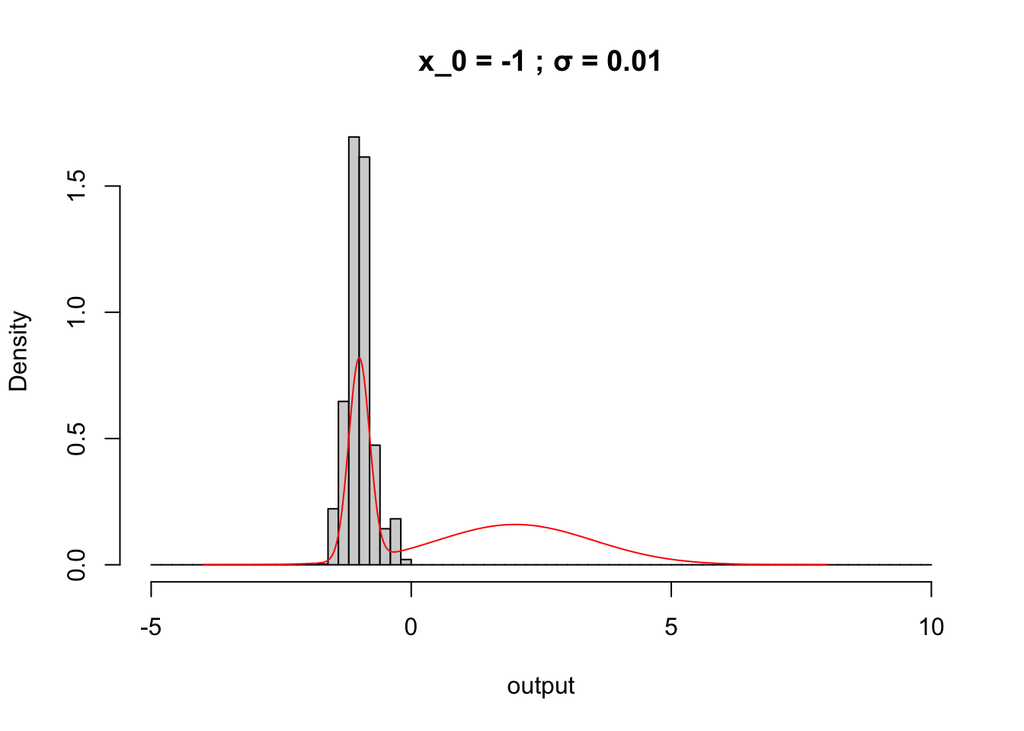

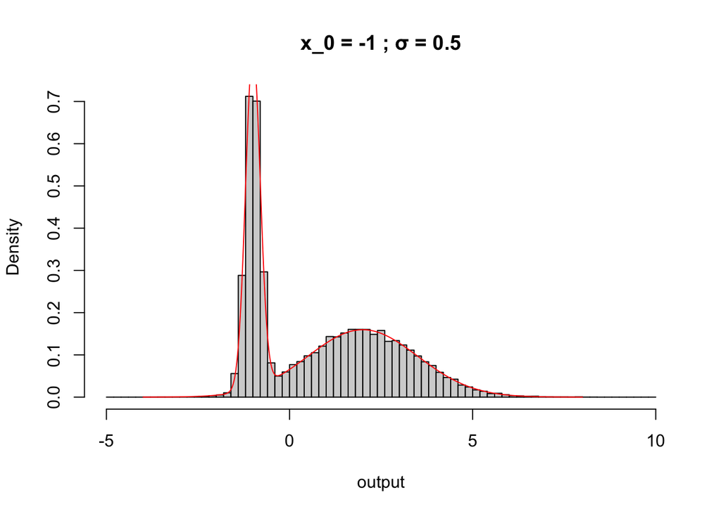

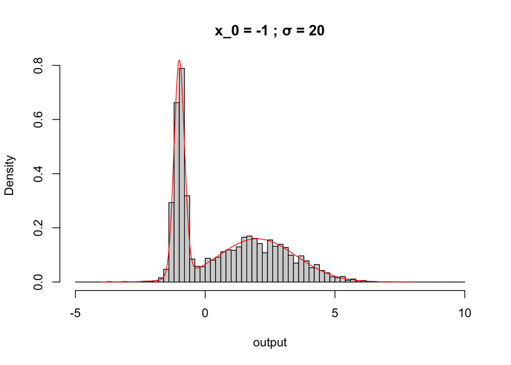

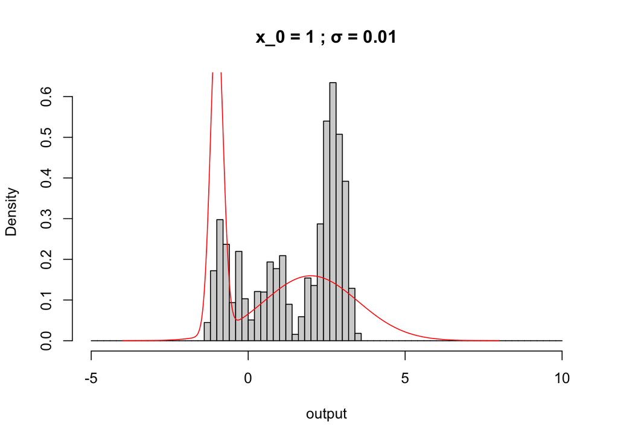

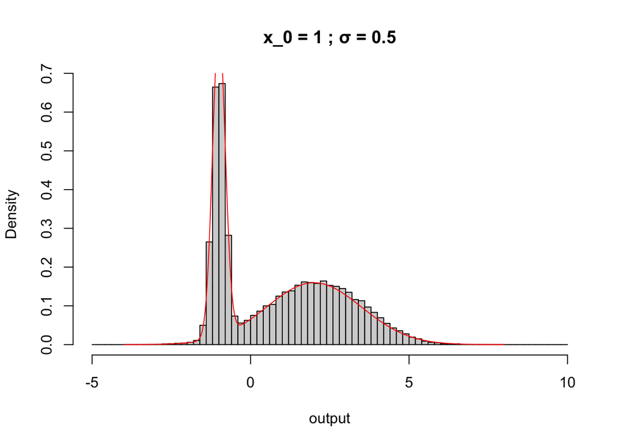

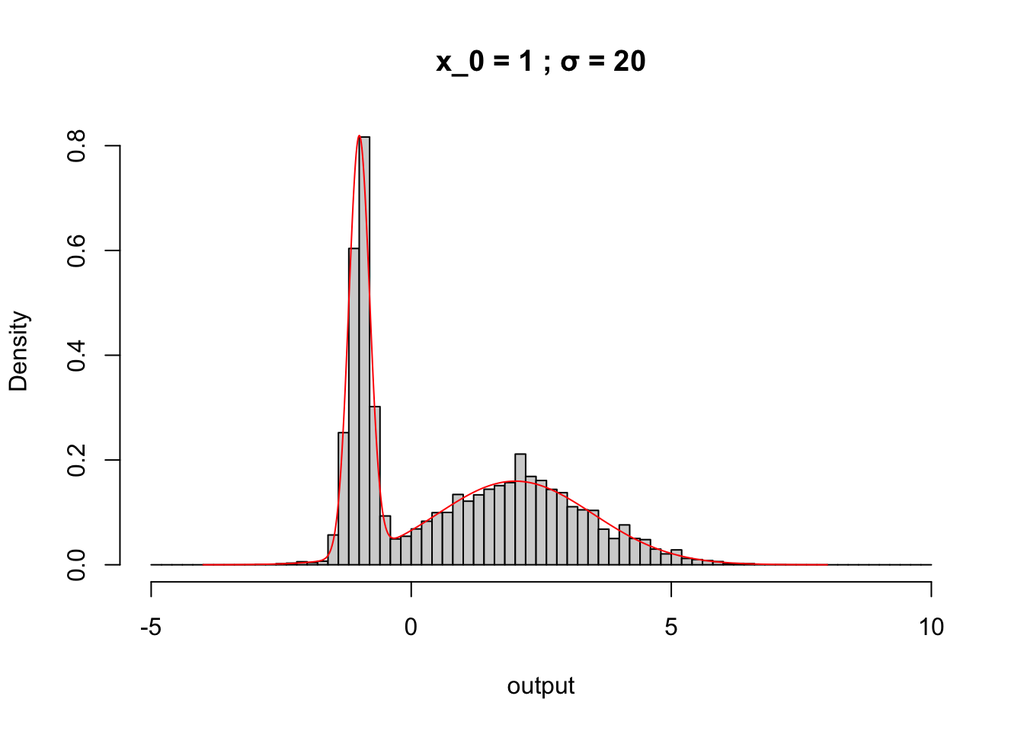

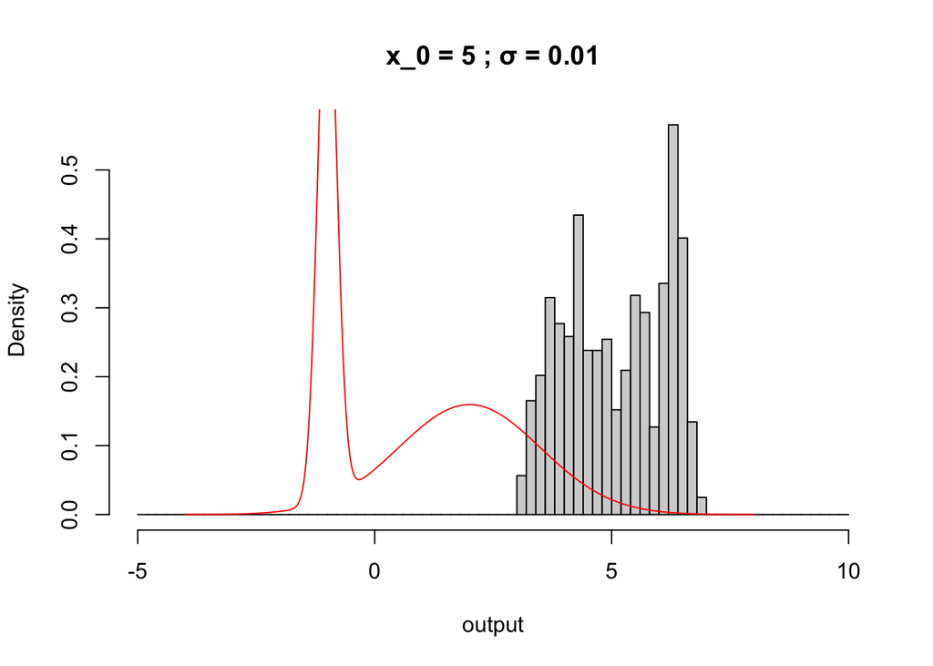

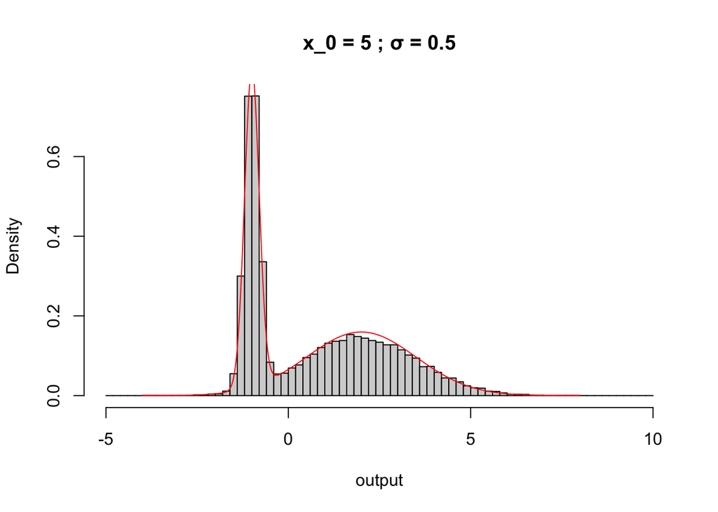

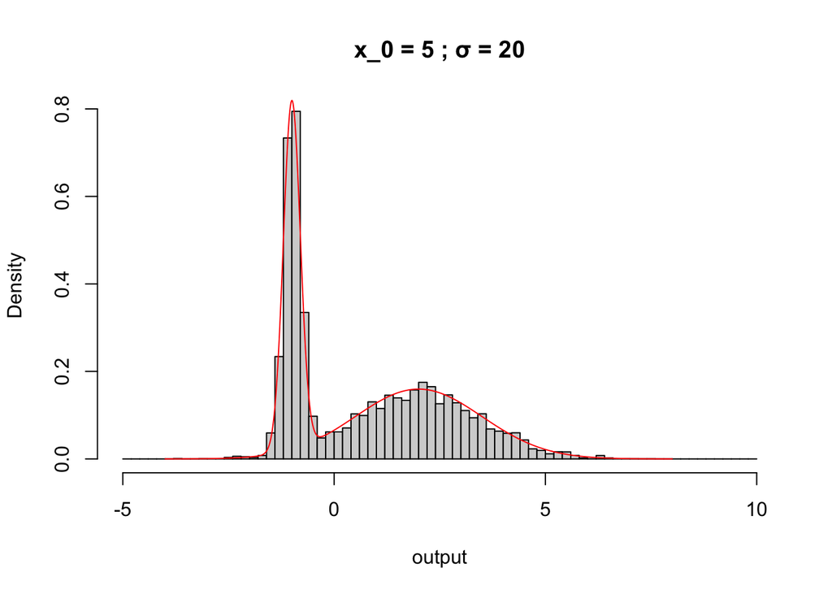

```r
for (x0 in x0_vals) {
  for (s in sigma_vals) {
    output <- mc.algorithm(x_0 = x0, n = 50000, sigma = s)
    hist(output, probability = TRUE,
         main = paste("x_0 =", x0, "; σ =", s),
         breaks = seq(-5, 10, by = 0.2))
    lines(x, f(x), col = "red")
  }
}
```

Looking at the outputs, we can see that sigma too small means the algorithm gets stuck and doesn’t explore the space sufficiently. Conversely sigma too large, meaning some proposals will jump beyond the reasonable possibilities of the target distribution and be rejected and the Markov chain won’t move enough.